# ANOVA Assumptions

## Introduction

- Previous: one sample, two samples
- Now: more than two groups, continuous outcome
  - One-way ANOVA
  - Kruskal-Wallis
  - posthoc testing
- This lecture: ANOVA assumptions

## `R` Setup

```r
library(tidyverse)
library(ssstats)
commute_times <- read_csv("https://raw.githubusercontent.com/samanthaseals/SDSI/refs/heads/main/files/data/lectures/4-2-commute_times.csv")
citations <- read_csv("https://raw.githubusercontent.com/samanthaseals/SDSI/refs/heads/main/files/data/lectures/4-4-citations.csv")
academy_scores <- read_csv("https://raw.githubusercontent.com/samanthaseals/SDSI/refs/heads/main/files/data/lectures/4-1-academy_scores.csv")
```

## ANOVA Assumptions

- We can represent ANOVA with the following model:

$$y_{ij} = \mu + \tau_i + \varepsilon_{ij}$$

- where:
  - $y_{ij}$ is the $j^{\text{th}}$ observation in the $i^{\text{th}}$ group,
  - $\mu$ is the overall (grand) mean,
  - $\tau_i$ is the treatment effect for group $i$, and
  - $\varepsilon_{ij}$ is the error term for the $j^{\text{th}}$ observation in the $i^{\text{th}}$ group.

## ANOVA Assumptions

- We assume that the error term follows a normal distribution with mean 0 and a constant variance, $\sigma^2$. i.e.,

$$\varepsilon_{ij} \overset{\text{iid}}{\sim} N(0, \sigma^2)$$

- Very important note: **the assumption is on the error term** ($\varepsilon_{ij}$) and NOT on the outcome ($y_{ij}$)!

## ANOVA Assumptions

- We will use the residual (the difference between the observed value and the predicted value) to assess assumptions:

$$e_{ij} = y_{ij} - \hat{y}_{ij}$$

- Note that in the case of one-way ANOVA, the predicted value of $y$ is the *group mean*.

## ANOVA Assumptions: Graphical Assessment

- **Normality**: quantile-quantile plot
  - Should have points close to the 45$^\circ$ line
  - We will focus on the “center” portion of the plot
- **Variance**: scatterplot of the residuals against the predicted values
  - Should be “equal spread” between the groups
  - No “pattern”

## Graphical Assessment of Assumptions (`R`)

- We will use the `anova_check()` function from `library(ssstats)` to assess normality.

```r
dataset_name |> anova_check(outcome = continuous_variable,
                       grouping = grouping_variable)
```

**1**

`outcome`: the continuous variable being compared across groups.

**2**

`grouping`: the categorical variable defining the groups (must have at least 2 levels).

- This will provide the the Q-Q plots and variance scatterplot necessary to assess the ANOVA assumptions.

## Example 1

- Recall our first question: does commute time differ across the four districts?

```r
commute_times |> anovas(outcome = commute_minutes,
                        grouping = district)
```

```
One-way ANOVA

Source      df         SS       MS      F  p-value
─────────────────────────────────────────────
district     3   120.0100  40.0033  0.780    0.507
Residuals  116  5945.7900  51.2568
─────────────────────────────────────────────


Hypotheses (district):
H₀: All group means are equal (no effect of district)
H₁: At least one group mean differs (effect of district exists)
Test statistic: F(3, 116) = 0.78
p-value: 0.507
Conclusion: Fail to reject the null hypothesis (p = 0.507 ≥ α = 0.050)
```

## Example 1

- Checking the assumptions,

```r
commute_times |> anova_check(outcome = commute_minutes,
                             grouping = district)
```

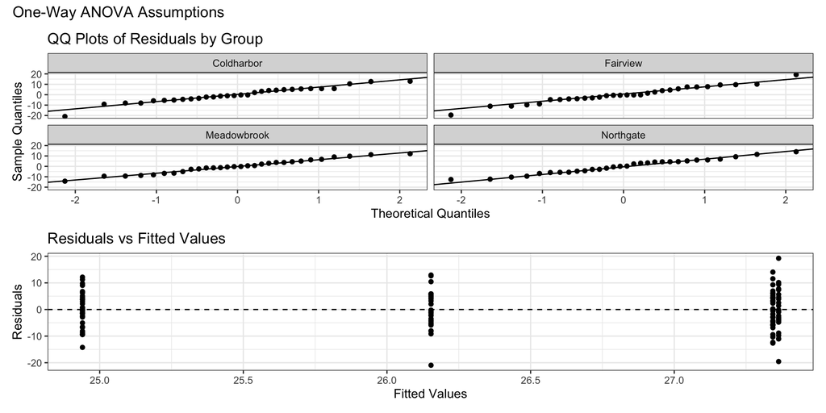

## Example 1

- If it’s hard to “see” the qq plots, we can “zoom in” using `one_qq()`,

```r
commute_times |> filter(district == "Coldharbor") |> one_qq(commute_minutes)
```

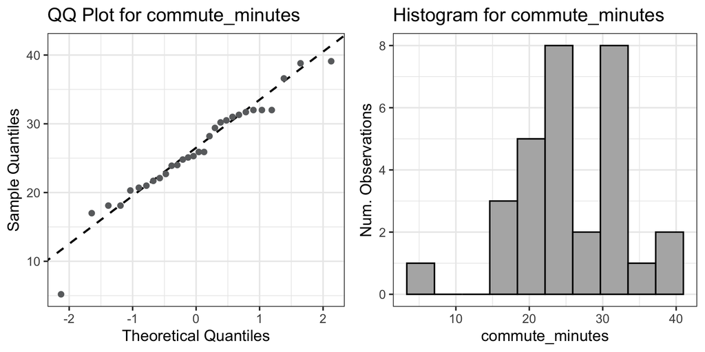

## Example 1

- If it’s hard to “see” the qq plots, we can “zoom in” using `one_qq()`,

```r
commute_times |> filter(district == "Fairview") |> one_qq(commute_minutes)
```

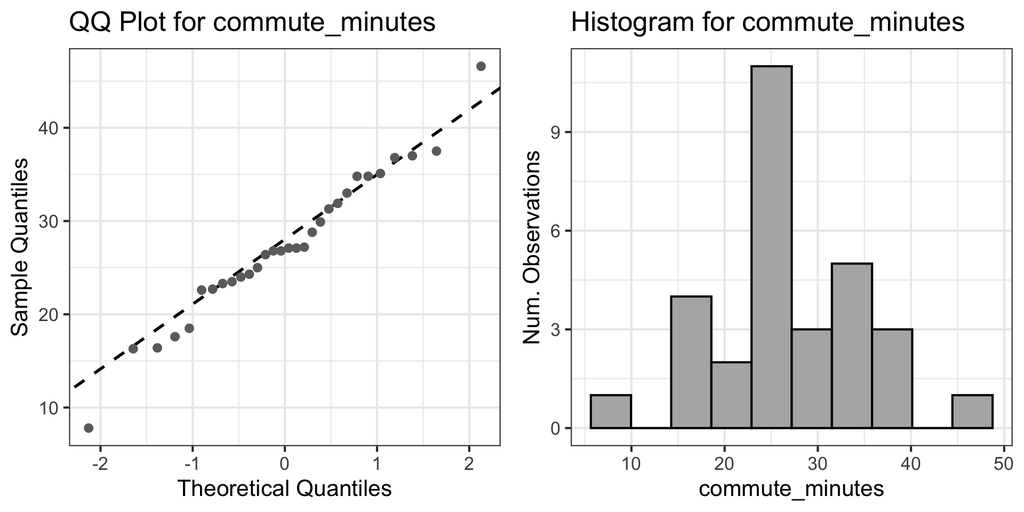

## Example 1

- If it’s hard to “see” the qq plots, we can “zoom in” using `one_qq()`,

```r
commute_times |> filter(district == "Meadowbrook") |> one_qq(commute_minutes)
```

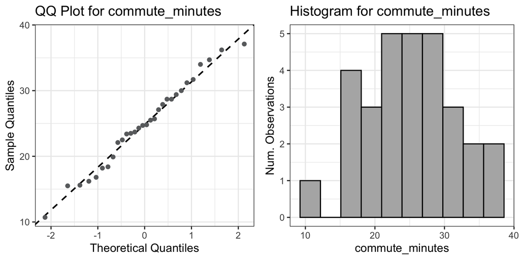

## Example 1

- If it’s hard to “see” the qq plots, we can “zoom in” using `one_qq()`,

```r
commute_times |> filter(district == "Northgate") |> one_qq(commute_minutes)
```

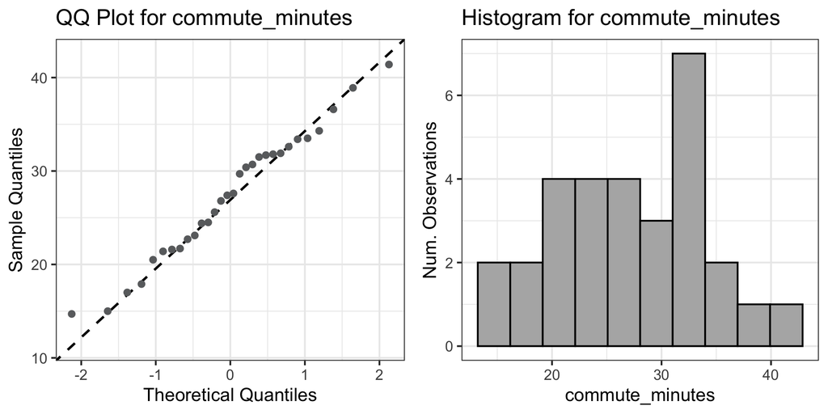

## Example 1

- Final assessment:
  - Normality: fine
  - Variance: ehhhh…?

## Brown-Forsythe-Levine Test

- When we are not confident making a call graphically, we can formally check the variance.
  - The analytic approach:
    - Transform $y_{ij}$ by subtracting off its group median.
    - Run ANOVA on these transformed values.
- **Hypotheses:**
  - $H_0$: $\sigma_1^2=\sigma_2^2=\hdots=\sigma_k^2$
  - $H_1$: population variances are not all equal
- **Test Statistic:**
  - $F_0$ on transformed data

## Checking Variance (`R`)

- We will use the `multiple_variances()` function from `library(ssstats)` to formally test the equality of variances.

```r
dataset_name |> multiple_variances(outcome = continuous_variable,
                                   grouping = grouping_variable,
                                   alpha = alpha_level)
```

**1**

`outcome`: the continuous variable being compared across groups.

**2**

`grouping`: the categorical variable defining the groups (must have at least 2 levels).

**3**

`alpha`: the significance level; default is `0.05`.

## Example 1

- Checking the variance,

```r
commute_times |> multiple_variances(outcome = commute_minutes,
                                    grouping = district)
```

```
Brown-Forsythe-Levene test for equality of variances

s²[Coldharbor] = 50.8543 (s = 7.1312)
s²[Fairview] = 62.2279 (s = 7.8885)
s²[Meadowbrook] = 44.1666 (s = 6.6458)
s²[Northgate] = 47.7784 (s = 6.9122)

Hypotheses:
H₀: All group variances are equal (no effect of district on variance)
H₁: At least one group variance differs (effect of district on variance exists)
Test statistic: F(3, 116) = 0.129
p-value: 0.943
Conclusion: Fail to reject the null hypothesis (p = 0.943 ≥ α = 0.050)
```

## Example 1

- **Hypotheses**
  - $H_0: \sigma^2_{\text{M}} = \sigma^2_{\text{C}} = \sigma^2_{\text{N}} = \sigma^2_{\text{F}}$
  - $H_1:$ at least one district is different
- **Test Statistic and *p*-Value**
  - $F_0 = 0.129$
  - $p = 0.943$
- **Rejection Region**
  - Reject $H_0$ if $p < \alpha$; $\alpha = 0.05$
- **Conclusion and Interpretation**
  - Fail to reject $H_0$. There is not sufficient evidence to suggest that there is a difference in the variance of commute times between the districts.

## Example 2

- Do assessment scores differ across the three training academies (Meadowbrook, Coldharbor, and Northgate)?

```r
academy_scores |> anovas(outcome = score,
                         grouping = academy)
```

```
One-way ANOVA

Source     df         SS        MS      F  p-value
─────────────────────────────────────────────
academy     2   786.9215  393.4607  5.898    0.004
Residuals  93  6204.2681   66.7126
─────────────────────────────────────────────


Hypotheses (academy):
H₀: All group means are equal (no effect of academy)
H₁: At least one group mean differs (effect of academy exists)
Test statistic: F(2, 93) = 5.898
p-value: 0.004
Conclusion: Reject the null hypothesis (p = 0.004 < α = 0.050)
```

## Example 2

- Looking at the assumptions graphically,

```r
academy_scores |> anova_check(outcome = score,
                              grouping = academy)
```

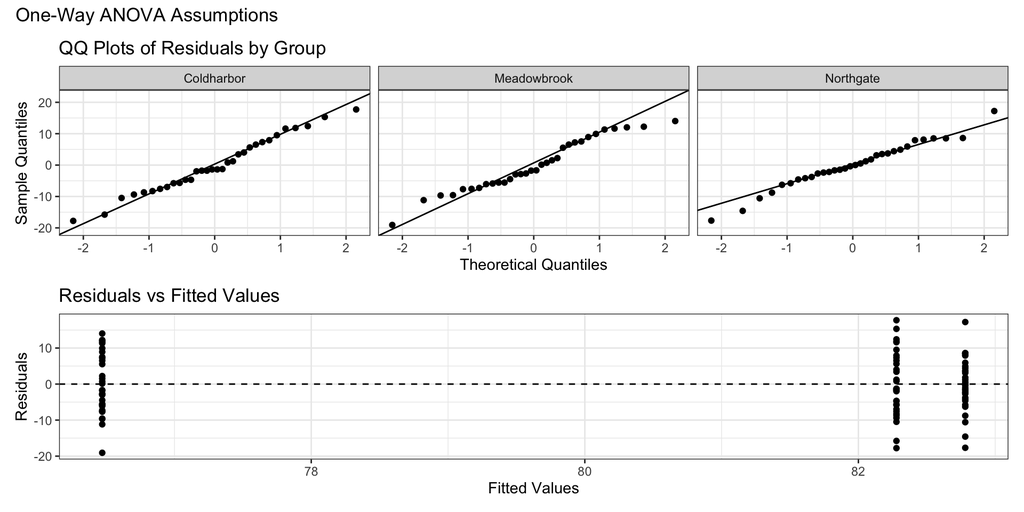

## Example 2

- Verifying the variance assumption,

```r
academy_scores |> multiple_variances(outcome = score,
                                     grouping = academy)
```

```
Brown-Forsythe-Levene test for equality of variances

s²[Coldharbor] = 78.2889 (s = 8.8481)
s²[Meadowbrook] = 69.3266 (s = 8.3263)
s²[Northgate] = 52.5222 (s = 7.2472)

Hypotheses:
H₀: All group variances are equal (no effect of academy on variance)
H₁: At least one group variance differs (effect of academy on variance exists)
Test statistic: F(2, 93) = 0.914
p-value: 0.404
Conclusion: Fail to reject the null hypothesis (p = 0.404 ≥ α = 0.050)
```

## Example 2

- **Hypotheses**
  - $H_0: \sigma^2_{\text{M}} = \sigma^2_{\text{C}} = \sigma^2_{\text{N}}$
  - $H_1:$ at least one district’s academy is different
- **Test Statistic and *p*-Value**
  - $F_0 = 0.914$
  - $p = 0.404$
- **Rejection Region**
  - Reject $H_0$ if $p < \alpha$; $\alpha = 0.05$
- **Conclusion and Interpretation**
  - Fail to reject $H_0$. There is not sufficient evidence to suggest that there is a difference in the variance of assessment scores between the academies

## Example 3

- Okonkwo’s last one for the day: “Traffic enforcement wants budget for more radar units. Their pitch is that citation activity is way higher in some districts than others. Before I sign off, let’s check the citation counts across the four districts.”
- We will use the `citations` dataset to answer the following question:
  - Does the number of citations issued per officer differ across the four districts?

## Example 3

- Does the number of citations issued per officer differ across the four districts?

```r
citations |> anova_check(outcome = citations,
                         grouping = district)
```

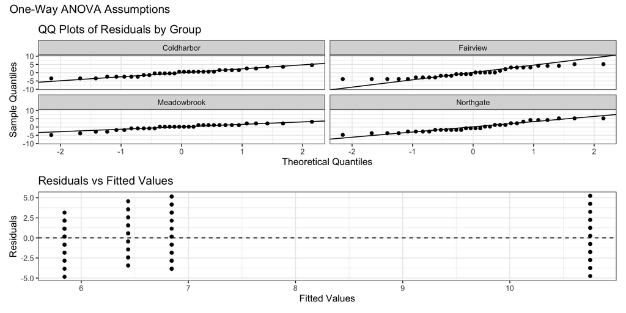

## Example 3

- Does the number of citations issued per officer differ across the four districts?

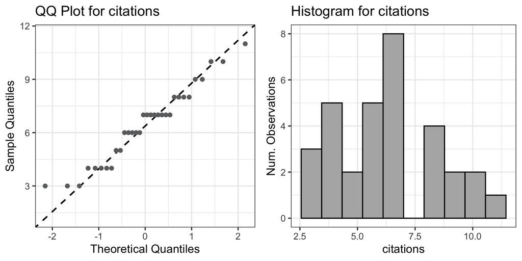

## Example 3

- Does the number of citations issued per officer differ across the four districts?

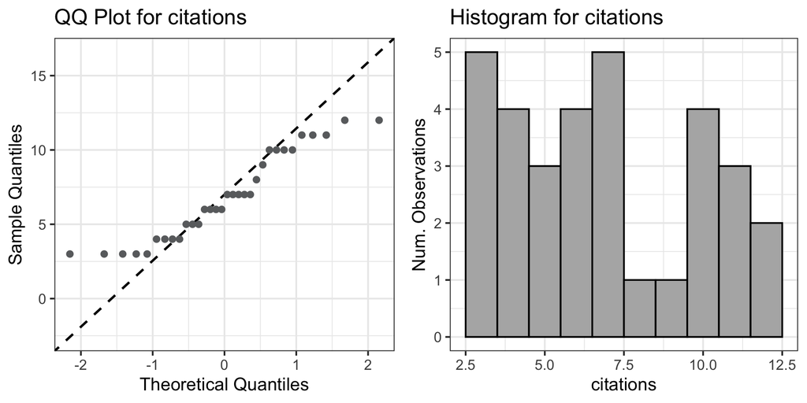

## Example 3

- Verifying the variance assumption,

```r
citations |> multiple_variances(outcome = citations,
                                grouping = district)
```

```
Brown-Forsythe-Levene test for equality of variances

s²[Coldharbor] = 4.5766 (s = 2.1393)
s²[Fairview] = 8.7167 (s = 2.9524)
s²[Meadowbrook] = 3.3619 (s = 1.8335)
s²[Northgate] = 8.9677 (s = 2.9946)

Hypotheses:
H₀: All group variances are equal (no effect of district on variance)
H₁: At least one group variance differs (effect of district on variance exists)
Test statistic: F(3, 124) = 4.237
p-value: 0.007
Conclusion: Reject the null hypothesis (p = 0.007 < α = 0.050)
```

## Example 3

- **Hypotheses**
  - $H_0: \sigma^2_{\text{M}} = \sigma^2_{\text{C}} = \sigma^2_{\text{N}} = \sigma^2_{\text{F}}$
  - $H_1:$ at least one district is different
- **Test Statistic and *p*-Value**
  - $F_0 = 4.237$
  - $p = 0.007$
- **Rejection Region**
  - Reject $H_0$ if $p < \alpha$; $\alpha = 0.05$
- **Conclusion and Interpretation**
  - Reject $H_0$. There is sufficient evidence to suggest that there is a difference in the variance of citations between the districts.

## Wrap Up

- This lecture introduced assessing assumptions for one-way ANOVA.
  - Normality: graph only
  - Variance: graph and test available
- However, we have not yet discussed what to do about a broken assumption…
- In the future:
  - Nonparametric alternative
  - Posthoc testing